# State of the Union Speech Analysis

Team 3 (Daniel Nachajon, Manu Singh ,Uday Bhaskar, Yimei Liu ,Tianhao Lu, Daniel Kost-Stephenson, Daniel Ramirez Soto)

May 12, 2016

### Motivation

The United States constitution calls upon the President of the United States to periodically uprise the congress about the state of the Union. SOTU’s as they are called, is used to define the execute agenda. The President, uses this opportunity to spell out this vision for the country. It is an opportunity to reflect on the challenges the nation faces. Since, SOTU’s are annual reflections of the Chief Exectuve on major events and trends affecting the nation, one can think of them as a repetitve observation into the status of the union, as it were. The data was provided as 224 speech text files and certain pre-processing is required.

### Initial Processing the Data

We started with data exploration to see how the sentiment of SOTU varied over the years. It was an intresting trend to observe as the nation has been through a lot of challenges both internal and external. It also had some exceptional thinkers and oraters as its Presidents.

### Sentiment Analysis

A list of positive words and negative words were taken from nltk corpus. For each SOTU document, the percentage of negative words was calculated. Then a graph was plotted with percentage of negative words per SOTU.

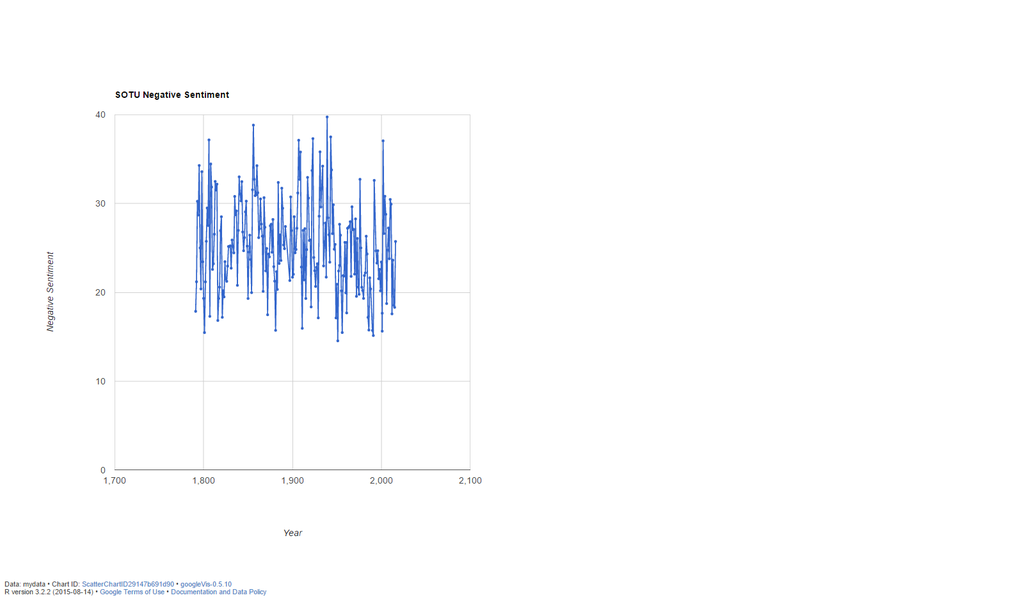

The graph shows negative sentiment of the SOTU speech. It is good to bring your attention to the period between 1900-1950. There are a lot of spikes, due to the World wars and the great depression. The most negative SOTU of recent past was after 9/11.

## Idealogue Analysis

Next we wanted to see how the political idealogue has evolved over the years. Based on a real politics analysis, a tagged set of SOTUs were taken. The SOTU’s were tagged with dominant idealogue. 0 - Left leaning 1 - center 2- Right leaning

A document vector was generated for each SOTU. A document vector was generated, but assigning a number to every word and counting the number of times the word appeared in the document. An SVM was trained with the tagged vectors and then was used to predict the idealogue of a SOTU. The graph is along the expected lines, majority of STOU’s are right leaning, espcially before 1980’s. Some intresting exceptions are a few STOU in the early 1900’s. That period was during the Teddy Roosevalt’s presidency.

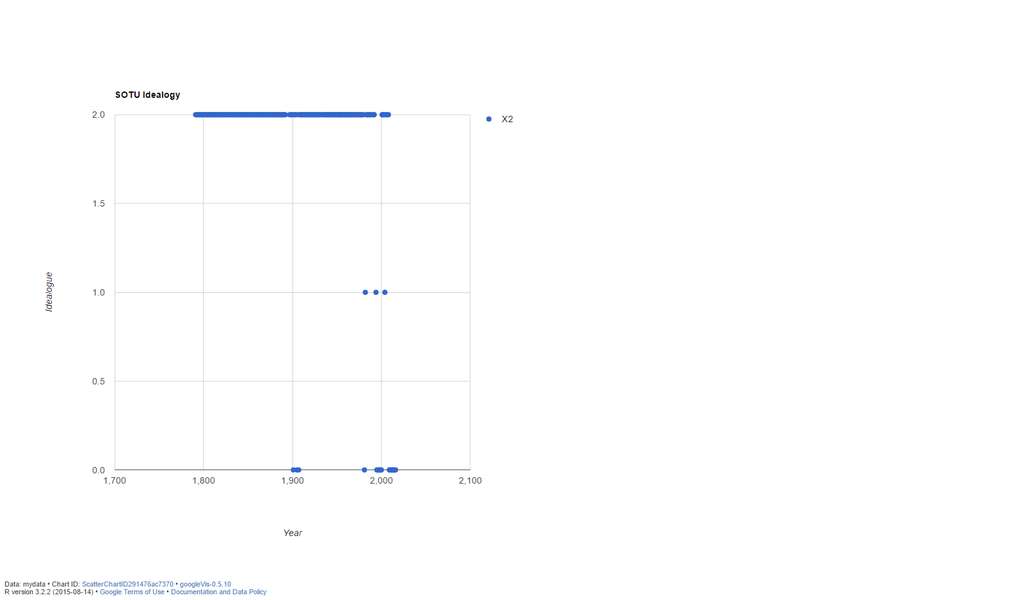

## Dems vs GOP

In this section, differences between the Democratic and Republican Parties are discussed. Several interesting differences can be observed throughout the analysis. One important factor worth noting is the difference in political ideology between the Democrats and Republicans over time. The Before 1900, the Democrats were known to be right of the Republican party on the political spectrum. Today, the Republicans are right of the Democrats and this political inversion occured somewhere between 1932-1964. First, we examine the entire corpus of Democratic and Republican State of the Union Addresses and look at differences in word usage between the two parties (words by party are adjusted for total number of words used). Displayed is the difference in the amount of times a certain word is used (by either a Democratic or Republican president) over the course of the given timeframe. Words like America, family, economy, education, future and health are common for Republicans while words like public, service, united and war are associated with Democrats. Most of these make sense, with the possible of war. A possible explanation for this is that Franklin Delano Roosevelt was the Democratic president during the second world war.

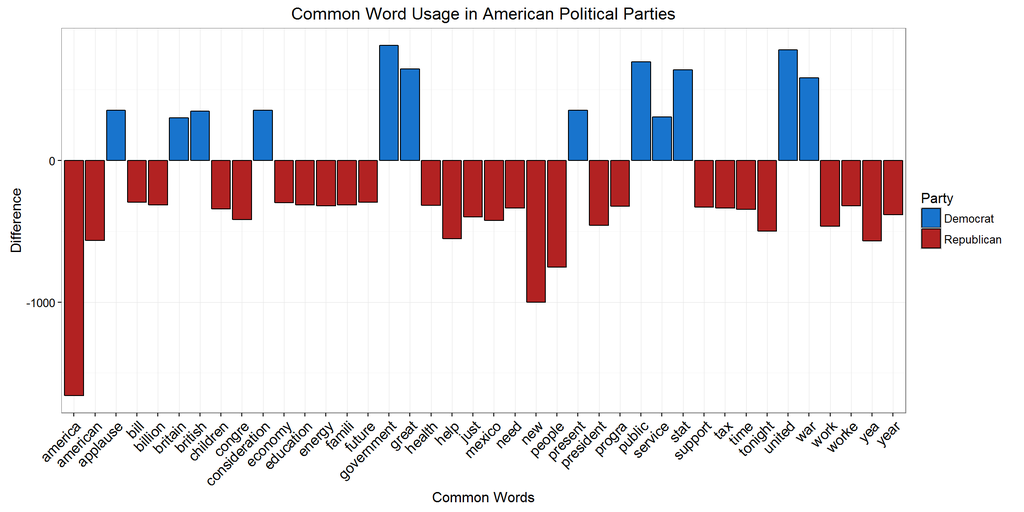

If we consider FDRs tenure as the turning point in the ideology of the democratic party, we can compare word usage before and after his presidency. Before his three terms, many of the same words are displayed in the previous graph.

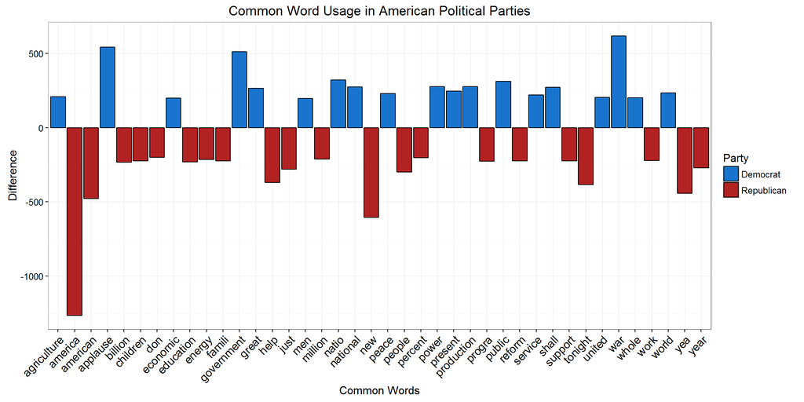

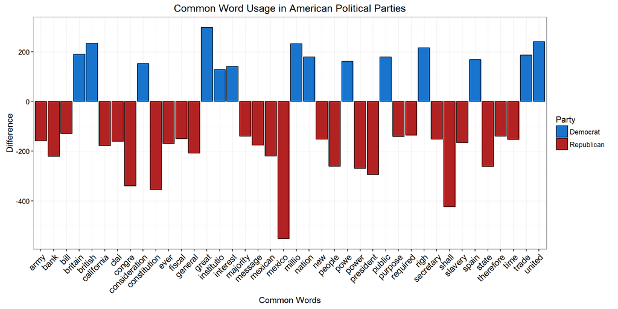

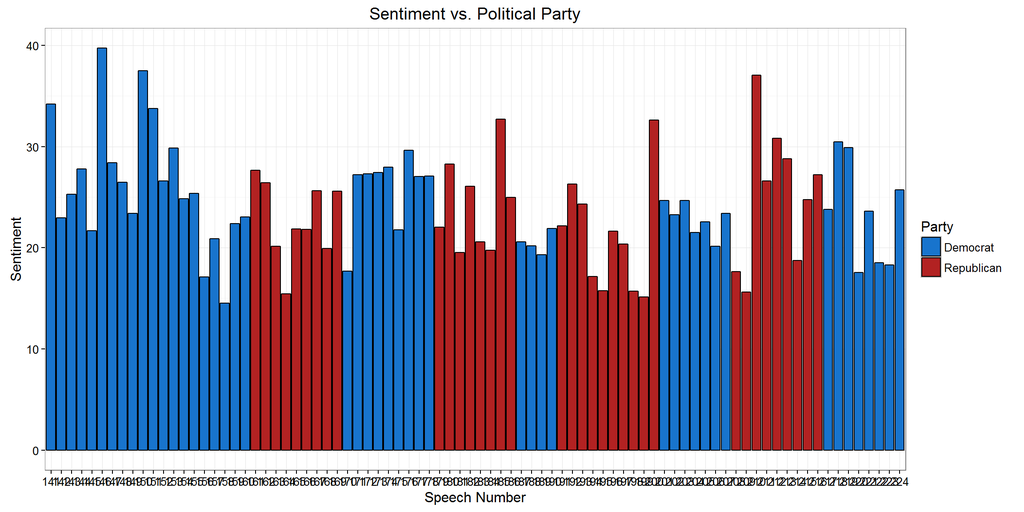

```
## [1] 24.77947
## [1] 23.255
```

Lastly, we investigate the previous presidencies by each of the political parties which of course corresponds to the time George W. Bush and Barack Obama are presidents. Bush tends to use terms like congress, united, act, commission, leglislation and great, while Obama uses wods such as government, tariff, treatment, condition and trust. Interestingly, Obama had a lower sentiment score than Bush, but their choice of words seems to be fairly consitent with the respective ideologies of their parties.

[figure not shown]

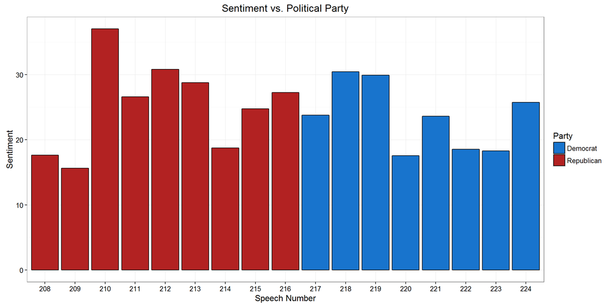

```
## [1] 23.49269
## [1] 25.25458
```

## Clustering of phrases in SOTU

We subject each speech to a simple processing. Firstly, punctuation is removed from the texts because it carries no immediate information and we do not seek to model higher order grammatical trends accross time. Next, all the words are changed to lower case to avoid considering *Nation* and *nation* as different words when humans would naturally understand them to be the same.

Next we remove the so-called “Stop-words” which include those like *the* and *in*. These are words which glue speech together but do not tend to convey information. After several preliminary runs of the code, I also removed a list of words which appeared important but when I looked a future clustering analyses they seemed to be red-herring.

Finally, we consider a standard practice in text processing called Stemming which is a heuristic approach to truncate words to similar roots or stems for better comparisons. I was somewhat disappointed with R’s package **tm** ability to stem so I just used a few simple heuristics of my own to get rid of plurals and leave the rest myself.

#### Document-Term Matrix

A key data structure for this work is a frequency count matrix of words used in our reduced lexicon. This matrix has a dimensions number of documents (224) by aggregate word count. The elements of this matrix are simple counts. So if $A_{i,j} = 10$ it means that the $i^{th}$ document has 10 instances of the $j^{th}$ word.

Our DTM matrix

```
## <<DocumentTermMatrix (documents: 224, terms: 24837)>>
## Non-/sparse entries: 343108/5220380
## Sparsity           : 94%
## Maximal term length: 20
## Weighting          : term frequency (tf)
```

The size of the lexicon has been reduced to under 25,000 words and we note that the vast majority of the entries of this matrix are 0.

## Cluster Analysis: 1790 - 2016

To gain some preliminary intuition, we run two different cluster analyses over the full dataset from 1790 to 2016.

### Dendrogram

A dendrogram draws its semblance from the classification of different species. Each word is considered by a vector over all the observations in all documents. Analysts have a choice of distance metric but for ease, we consider words “close” if they are “close” in the Euclidean sense. Then we group these up through a metric called Ward distance. This is a way of comparing two groups of vectors of potentially unequal size. If we consider group 1, $G_1$ of size $|G_1|$ and similarly group 2, $G_2$ then the Ward’s distance is given by:

$d(G_1, G_2) = \frac{|G_1||G_2|}{|G_1| + |G_2|} ||mean(G_1) - mean(G_2)||$

The dendrogram below shows the full expansion by Euclidean distance of the DTM and then we cluster the end leaf nodes into 7 groups by those which minimize the Ward’s distance.

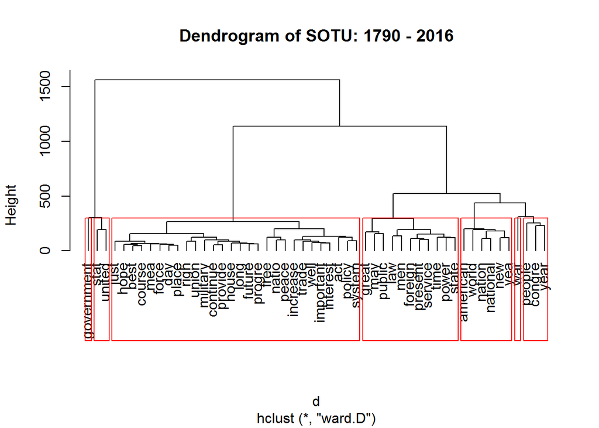

### K-means: 2 Cluster

Next we look at a more standard K-means algorithms using Euclidean distance. This is more of a macro-spective view that lets us see broad views into themes in the SOTUs.

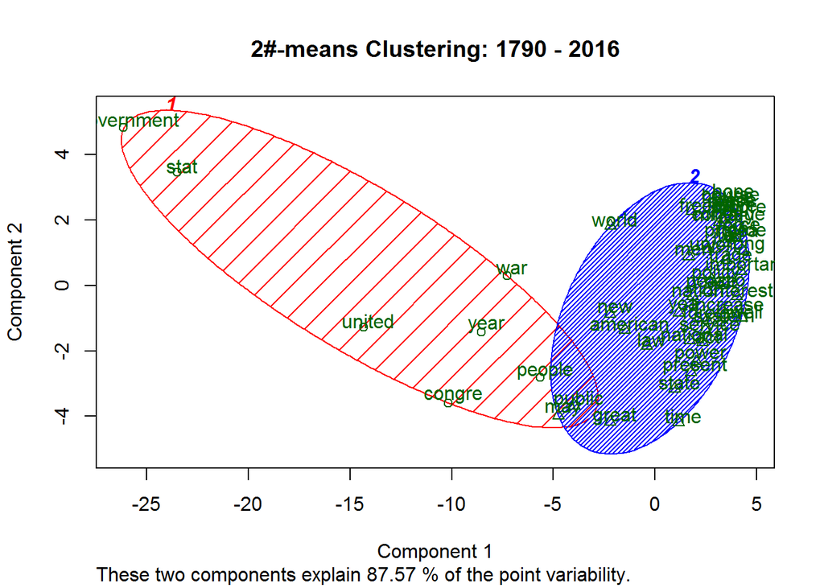

## Year-on-Year Major Changes

When we actually used this data, we convert each row (corresponding to a document) to a probability mass function by normalization. This allows us to compare speeches across different lengths. For each speech, made in year $t$ we consider the row of the DTM given by $u = v_t$ and that from the previous year, $w = v_{t-1}$. We compute the portion of $u$ which is orthogonal to $w$

$v = u - \frac{w^T u}{||w||}u$

# Multidimensional Scaling of Presidential Speeches

The best way to understand how the presidential speeches have evolved over the years, we decided to run multidimensional scaling (MDS) to understand the similarities and dissimilarities between president speech styles.

The data set was cleaned as per the usual requirements, the words were stemmed, stop words were removed, punctuation were removed, attached words were split up. The clean data set was now stored and used in the MDS analysis.

To understand the distance between presidential speeches the Shannon-Jensen metric was used in the calculation [Eiron, N., & McCurley, K. S. (2003, July). Analysis of anchor text for web search ACM.]. A ready-made function which computes the distance was employed and the results are now stored in an adjacency matrix format of dimension 41 x 41. Where any (i,j) element represents the distance between the presidents i and j.

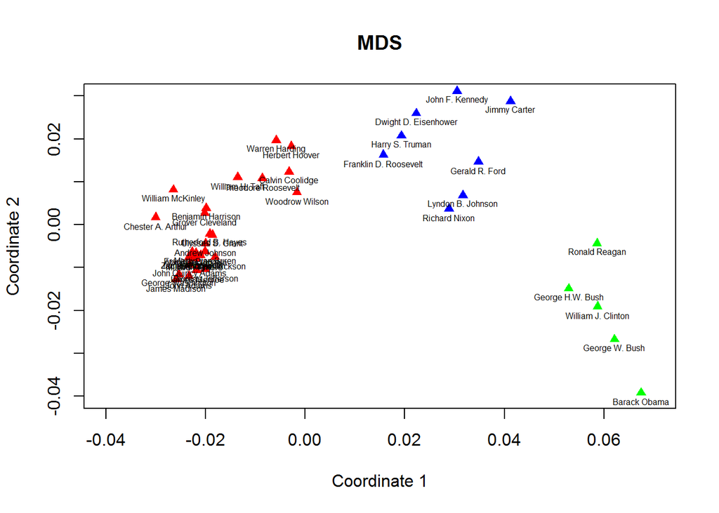

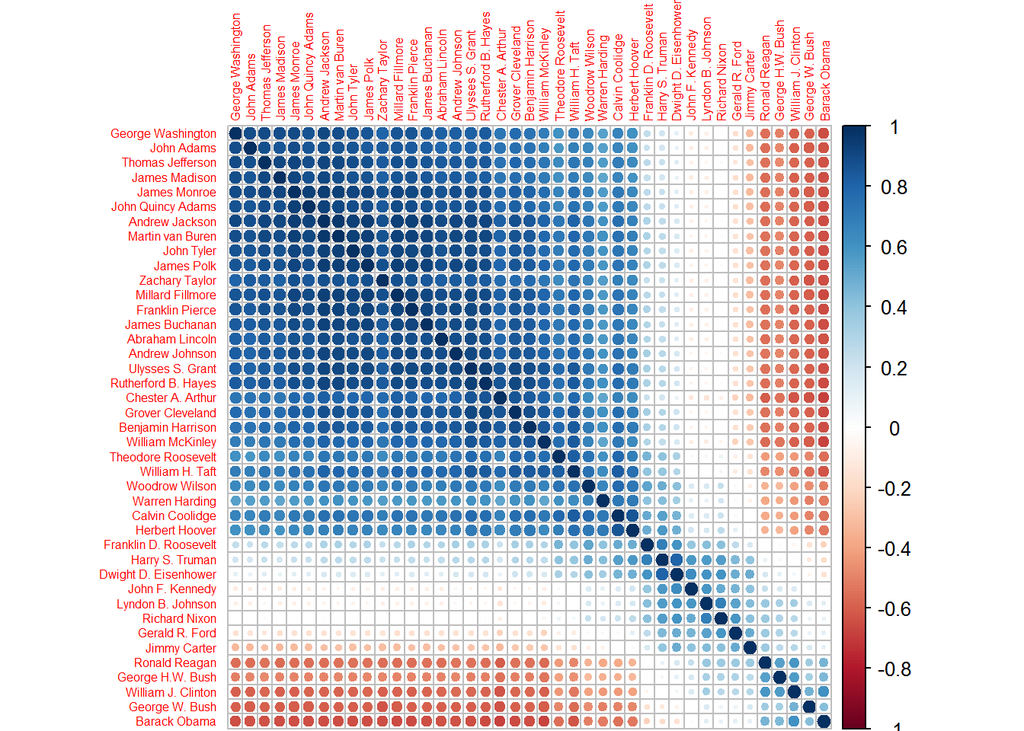

Another very interesting way of visualizing the distances between the presidents is by forming a network, where each node is a president and the distance between these presidents represents the speech similarity (if observed very close) or dissimilarity(if reasonably far). A Voronoi decomposition is uniquely determined by the distance matrix. (there is a 1:1 mapping possible) Thus this is an effective visualization of the distance matrix. This kind of a visualization become especially useful if we wanted to train an algorithm using KNN. Thus instead of searing for similar nodes throughout the data set. Usually this is very useful for representing large data sets. Thus instead of mapping all the points a voronoi decomposition plots only a select handful number of nodes (in KNN prediction now instead of sifting through the entire data set we only need to sift through these handful points, and when a similar node is found we search for the actual neighbors in that node’s voronoi cell).

In this case as the application was just to visualize and the data set was quite small, all the points have been plotted.

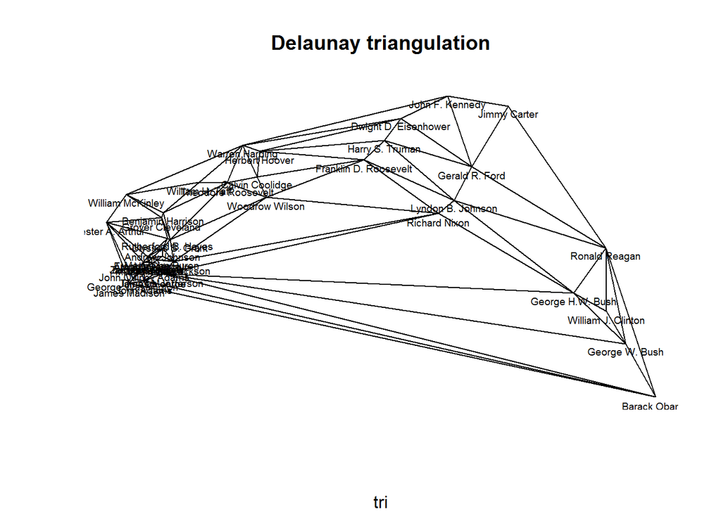

# Latent Dirichlet Allocation for Topic Cluster Analysis

We are looking for common topics. With LDA (Latent Dirichlet Allocation), we are going to create clusters of words, each group of words is a topic and each document have a relation with one topic. This approach gives us the possibility of answering question such what kind of documents are similar from others. What presidents talk about common topics. We are going to choose 10 topics.

Now, We show the ten words per topic. For instance our second topic is about Mexico and Constitution and topic three is about free nations

```
##       Topic 1      Topic 2        Topic 3   Topic 4      Topic 5
##  [1,] "the"        "mexico"       "world"   "the"        "the"
##  [2,] "government" "constitution" "people"  "men"        "year"
##  [3,] "upon"       "war"          "peace"   "law"        "000"
##  [4,] "public"     "power"        "nation"  "business"   "american"
##  [5,] "people"     "union"        "nations" "work"       "commission"
##  [6,] "congress"   "the"          "free"    "american"   "per"
##  [7,] "present"    "people"       "the"     "conditions" "service"
##  [8,] "000"        "treasury"     "freedom" "nation"     "secretary"
##  [9,] "time"       "president"    "our"     "man"        "government"
## [10,] "shall"      "states"       "but"     "there"      "department"
##       Topic 6    Topic 7      Topic 8      Topic 9          Topic 10
##  [1,] "public"   "war"        "states"     "the"            "and"
##  [2,] "the"      "state"      "united"     "federal"        "america"
##  [3,] "commerce" "union"      "government" "year"           "people"
##  [4,] "war"      "address"    "congress"   "program"        "americans"
##  [5,] "session"  "december"   "the"        "congress"       "work"
##  [6,] "treasury" "january"    "treaty"     "economic"       "american"
##  [7,] "peace"    "enemy"      "act"        "government"     "applause"
##  [8,] "year"     "men"        "state"      "administration" "year"
##  [9,] "objects"  "forces"     "subject"    "war"            "years"
## [10,] "measures" "production" "upon"       "national"       "let"
```

With this topics, We can classify each document. Additional with the information of the date and the president, we could create a Graph that helps us to understand, similar letters per topic and president. Topics are bigger in size that the documents, If it is a popular topic it is going to be greater that the others, the size of the edge in the graph is represented by the probability of having an accurate prediction. Also We use colors to identify the documents that were written by the same president.

[interactive chart not shown]

## A Deep Dive Analyis of George Bush’s SOTU’s

Let us now analyse the SOTU’s of George W Bush. We can try to predict how many appulse breaks a SOTU can get.

### An Aristotelian Mining of G.W.Bush’s Addresses 2001-2008 and Audience Applauses

We noticed the recordings of applauses from the audience in Bush’s SoTU addresses. As this information was not paid much attention to in text mining on these addresses thus far,we dedicate this section to an analysis on what Bush says that triggers audience to embrace him with applause.

### Data:

In all the addresses, only G.W.Bush’s has recordings of when audience applaud. He gave 9 speeches in total (including the extra one he delivered after 9/11). Interestingly, 8 of them have detailed recordings of applauses, except the one in 2003. This naturally poses a challenge to us: can we build a model from his other speeches, to predict when audience would applaud in his 2003 speech?

To get the true labels of where applauses occur in 2003 address, we found the audio recording of the speech at https://www.youtube.com/watch?v=FYypEx78950 and hand labeled the applauses in the text file. This file then becomes the source of testing data.

#### Bush’s applauses by year

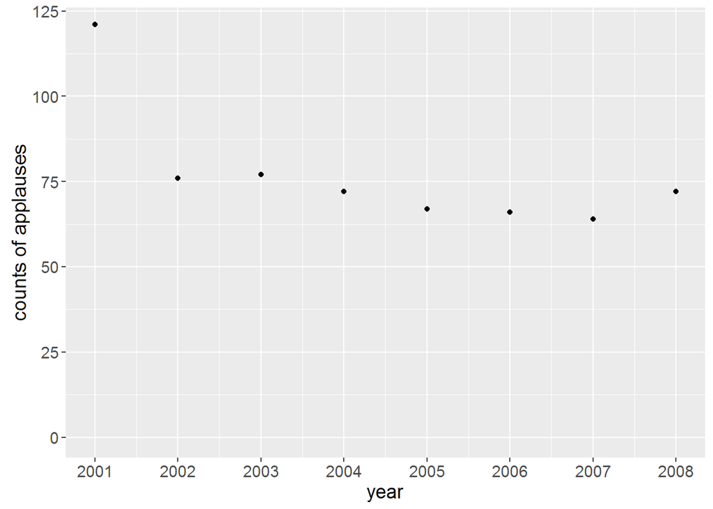

### Inspiration:

The inspiration for the analysis comes from what Aristotle defined as the 3 modes of persuasion, namely: pathos,ethos and logos. As a brief introduction:

**Pathos:** an appeal to the audienceâs emotions. May also include appeals to audience imagination and hopes; done when the speaker paints a scenario of positive future results of following the course of action proposed.

**Ethos:** an appeal to the authority or credibility of the presenter. It is how well the presenter convinces the audience that he or she is qualified to present (speak) on the particular subject.

**Logos:** logical appeal or the simulation of it. Normally used to describe facts and figures that support the speaker’s claims or thesis.

Essentially, we use these 3 modes in our daily conversations and we certainly expect president Bush to be masters of them when delivering the annual addresses. We would like to investigate what roles the 3 modes play in triggering audience applauses.

### Feature Engineering

Thus we carry an Aristotelian feature engineering phase. This is done in Python.(see code in *applause_feature.py*) To extract relevant features about each of the 3 modes, we did the following:

**Pathos:** As pathos is about emotions, we did a sentiment analysis on each sentence. Using the lexicon from http://sentiwordnet.isti.cnr.it/, we parsed each sentence from Bush’s addresses and built 3 features:  
*score:* sum of each word’s sentiment score in a sentence.  
*max:* max sentiment score from 1 word in the sentence  
*min:* min sentiment score from 1 word in the sentence\

**Ethos:** Ethos is appeal to authority. Intuitively, Bush would use the word ‘I’, not to add egoistic tone, but to convince the audience of his own authority. In other cases, he would use ‘we’ to refer to the Americans as an authoritative entity. Hence we extracted 2 features for Ethos:  
*i:* how many times ‘I’ occurs in a sentence  
*we:* how many times ‘we’ occurs in a sentence\

**Logos:** We took an naive approach to features with Logos. As it’s all about numbers and logic, we extracted Bush’s use of quantitative words in his addresses. The 2 features are:  
*has_num:* if quantitative words (900,‘million’,‘surged’, etc) appears in a sentence  
*num:* how many quantitiative words appears in a sentence \

Finally, we add 1 last feature *len* = word counts of the sentence

### Logistic Regression

We represented each sentence from Bush’s addresses as 1 data point. The training data is stored in **train_applause.csv** with 2055 rows. This file excludes the 2003 address as that’s to be used as the testing data.

```
##
## Call:
## glm(formula = label ~ ., family = "binomial", data = f[, 3:11])
##
## Deviance Residuals:
##     Min       1Q   Median       3Q      Max
## -2.1878  -0.7749  -0.6568   1.0906   2.0762
##
## Coefficients:
##              Estimate Std. Error z value Pr(>|z|)
## (Intercept) -2.058263   0.134964 -15.250  < 2e-16 ***
## len          0.026060   0.006058   4.302 1.69e-05 ***
## score        0.034567   0.119686   0.289  0.77272
## max          0.923982   0.347594   2.658  0.00786 **
## min         -0.409125   0.473228  -0.865  0.38729
## i            0.467909   0.105911   4.418 9.97e-06 ***
## we           0.198559   0.057299   3.465  0.00053 ***
## has_number  -0.099188   0.302235  -0.328  0.74278
## num          0.081556   0.158830   0.513  0.60762
## ---
## Signif. codes:  0 '***' 0.001 '**' 0.01 '*' 0.05 '.' 0.1 ' ' 1
##
## (Dispersion parameter for binomial family taken to be 1)
##
##     Null deviance: 2342.0  on 2054  degrees of freedom
## Residual deviance: 2246.8  on 2046  degrees of freedom
## AIC: 2264.8
##
## Number of Fisher Scoring iterations: 4
```

Having the model built, we would like to test its performance on the 2003 address by Bush. This speech has **281 sentences with 76 applauses** Our model achieves an accuracy of 72.6% on the data. While the accuracy doesn’t seem that high, we provide another evaluation below that shows the validity of the model.

### Evaluation: prediction vs real

For each applause, we definie a variable *Occ* as *position of the applause in the address*. For ecample, if applause 1 occurs after 121 words and the whole speech has 5473 words, Occ[1]=121/5473=2.21%, or **the first applause occurs at 2.21% of the speech.** (This is crucial to interpret the chart below.) There are 76 applauses so we obtain a vector with length 76.

Occ_original:[2.21%,2.87%,…96.13%,98.8%]

Similarly, we calculate the occ vector for the **predicted applauses** based on our model.

Occ_pred: [0.72%,1.77%,…97.7%,99.7%]. This vector contains 74 entries, as the model predicts 74 applauses.

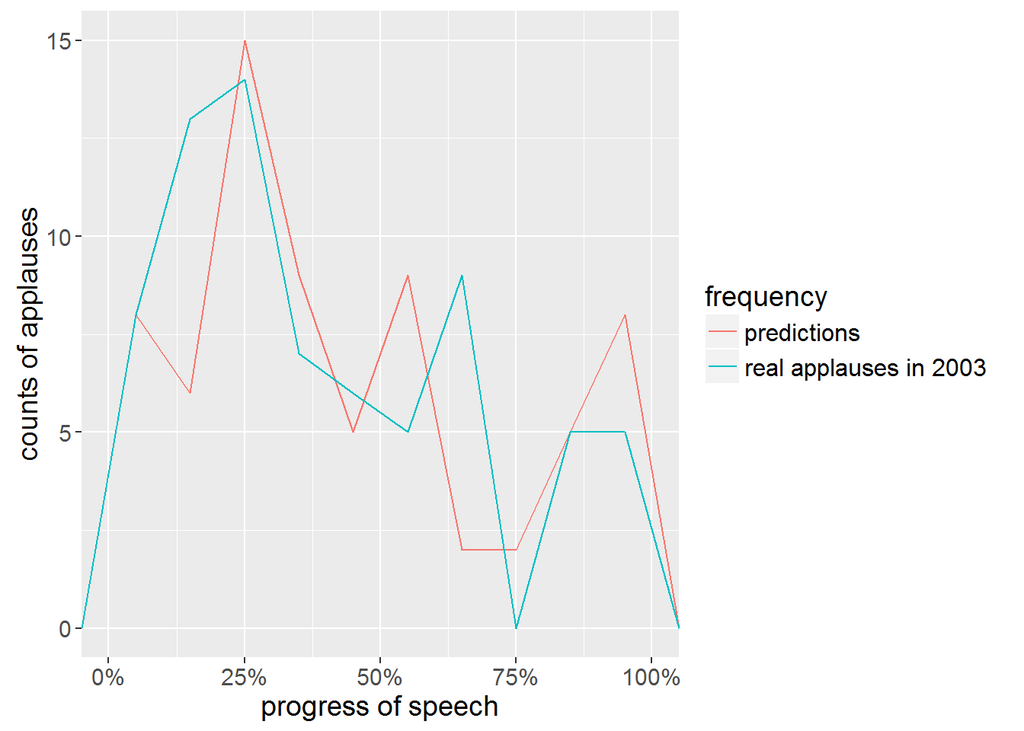

### Further Evaluation

Visually this comparison really gave us some confidence in the model. Our conclusion was that while the accuracy score wasn’t that high, the model was able to simulate audience’s reaction on a big scale as the speech progresses. We were curious to why the audience were so enthusiastic at the beginning and remained silent around when Bush is 80% in his speech.

Thus we did a bit more text mining on this speech. We divided the speech into 10 chuncks in sequence, each containing 10% of the words. For each chunk, we did a term frequency calculation (after stemming, removing stopwords, etc) and returned the top 3 words that Bush said the most during that section. So we have 30 words that roughly indicate the topics Bush addresses during his speech as the speech progresses. This was again done in *applause.py*

Then we add these words to the graph in where they occur during the speech. The picture is clear now: audiences gave the peak of applauses when Bush talked about economy at beginning(**tax, income, energy** ), still gave applauses (although less frequent) when he addressed some philanthropic topics (**Africa,aids children**). Then the audience got silent as Bush discusses terrorism and Iraqi war (**terror,Hussein,nuclear**), and finally gave another round of applauses at the notion of good old American dream. (**peace,America**)

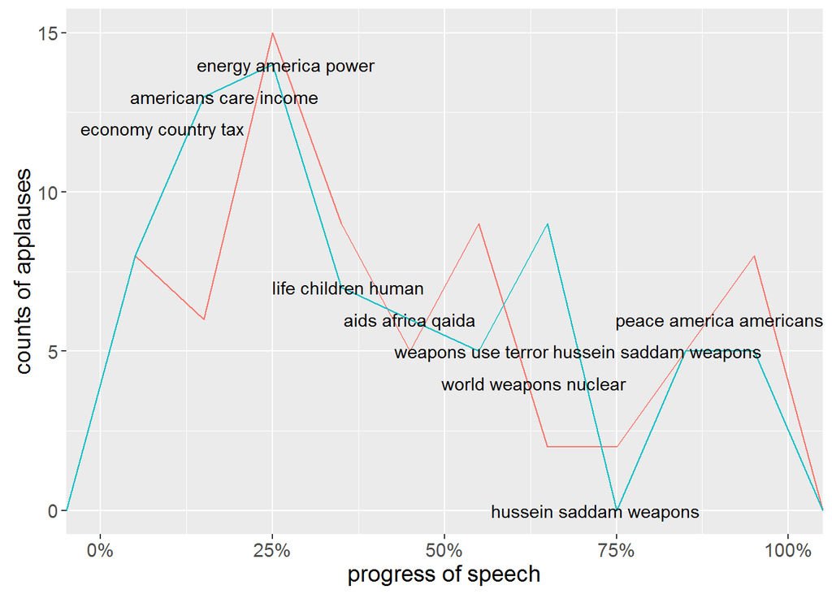